# Machine Learning Examples

Tayfun Gumus - ETM 58D - Spring 2018

# Assignment 1

## Esoph

First, we build a logistic regression model to see whether our variables significant or not for cancer.

```r
library(tidyverse)
```

```r
library(stats)
library(ggplot2)
cancer_model <- glm(cbind(ncases,ncontrols) ~ agegp + tobgp + alcgp , data = esoph , family = binomial() )
anova(cancer_model)
```

```
## Analysis of Deviance Table
##
## Model: binomial, link: logit
##
## Response: cbind(ncases, ncontrols)
##
## Terms added sequentially (first to last)
##
##
##       Df Deviance Resid. Df Resid. Dev
## NULL                     87    227.241
## agegp  5   88.128        82    139.112
## tobgp  3   19.085        79    120.028
## alcgp  3   66.054        76     53.973
```

We can clearly see age is key variable for cancer,since adding “Age” predictor causes a decrease on Residual Deviance by 88.128 . Then, alcohol consumption predictor helps our model fit better, again we can observe this by looking deviance residual. Finally, tobacco consumption also has effect on cancer which is smaller by comprasion to others. All these variables helps us to build a good model with better fit.

If we want to seek dependent effect of tobacco and alcohol, we should build a model loking at intersection effect of alcohol and tobacco consumption.

```r
cancer_model <- glm(cbind(ncases,ncontrols) ~ agegp + tobgp * alcgp , data = esoph , family = binomial() )
anova(cancer_model)
```

```
## Analysis of Deviance Table
##
## Model: binomial, link: logit
##
## Response: cbind(ncases, ncontrols)
##
## Terms added sequentially (first to last)
##
##
##             Df Deviance Resid. Df Resid. Dev
## NULL                           87    227.241
## agegp        5   88.128        82    139.112
## tobgp        3   19.085        79    120.028
## alcgp        3   66.054        76     53.973
## tobgp:alcgp  9    6.489        67     47.484
```

Reference: http://stat.ethz.ch/R-manual/R-devel/library/datasets/html/esoph.html

## Young People Survey’s Hobbies & Interests

```r
yr_data <-
read.csv("/Users/TCTAGUMUS/Documents/R işleri/youth_responses.csv",sep=",") %>%
filter(complete.cases(.)) %>%
# mutate(id=row_number()) %>%
tbl_df()
yr_pca<-
yr_data[,sapply(yr_data,class)=="integer"] %>%
select(History:Pets)
yr_mds_data <- yr_pca %>% select(History:Pets)
yr_dist <- 1 - cor(yr_mds_data)
#Apply MDS
yr_mds <- cmdscale(yr_dist,k=2)
colnames(yr_mds) <- c("x","y")
library(ggplot2)
#Set the seed because K-Means algorithm uses a search based method
set.seed(58)
#Apply K-Means
genre_cluster<-kmeans(yr_mds,centers=6)
##Get the clusters
mds_clusters<-
data.frame(genre=names(genre_cluster$cluster),
cluster_mds=genre_cluster$cluster) %>% arrange(cluster_mds,genre)
mds_clusters
```

```
##                     genre cluster_mds
## 1         Art.exhibitions           1
## 2                 Dancing           1
## 3               Gardening           1
## 4              Psychology           1
## 5                 Reading           1
## 6                 Theatre           1
## 7                 Writing           1
## 8             Mathematics           2
## 9                 Physics           2
## 10 Science.and.technology           2
## 11            Celebrities           3
## 12      Foreign.languages           3
## 13       Fun.with.friends           3
## 14                   Pets           3
```

[output cut: 18 more lines]

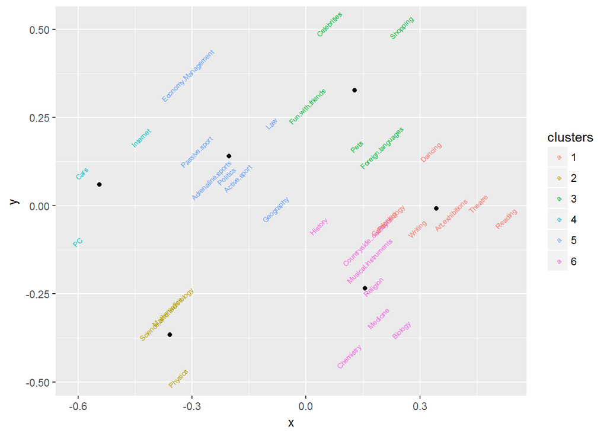

```r
ggplot(
    data.frame(yr_mds) %>% mutate(clusters=as.factor(genre_cluster$cluster),
    genres=rownames(yr_mds)),aes(x=x,y=y)) +
    geom_text(aes(label=genres,color=clusters),angle=45,size=2) +
    geom_point(data=as.data.frame(genre_cluster$centers),aes(x=x,y=y)
)
```

# Assignment 2 : Diamonds Data

I plotted carat vs price to see how price is changing according to carat and choosing cut value as a color, I aimed to see relations among price, cut and carat. In plot shown below, we can clearly see an increase in price with increase in carat but we can see all cuts(colors) thorughout price_range and this implies that cut is not significant by its own.

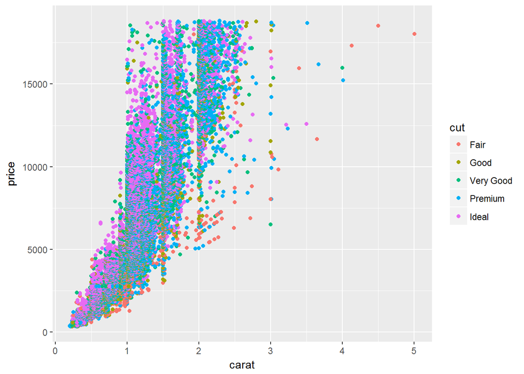

```r
library(rpart) #To construct CART models
library(rpart.plot) # It also includes titanic data
library(rattle) #For visualization
ggplot(diamonds) + geom_point(aes(x = carat, y = price, color = cut ))
```

I also plotted dimensions vs price. Looking plot, we can conclude that there is a positive slope and this implies increasing x,y,z results increasing in price.

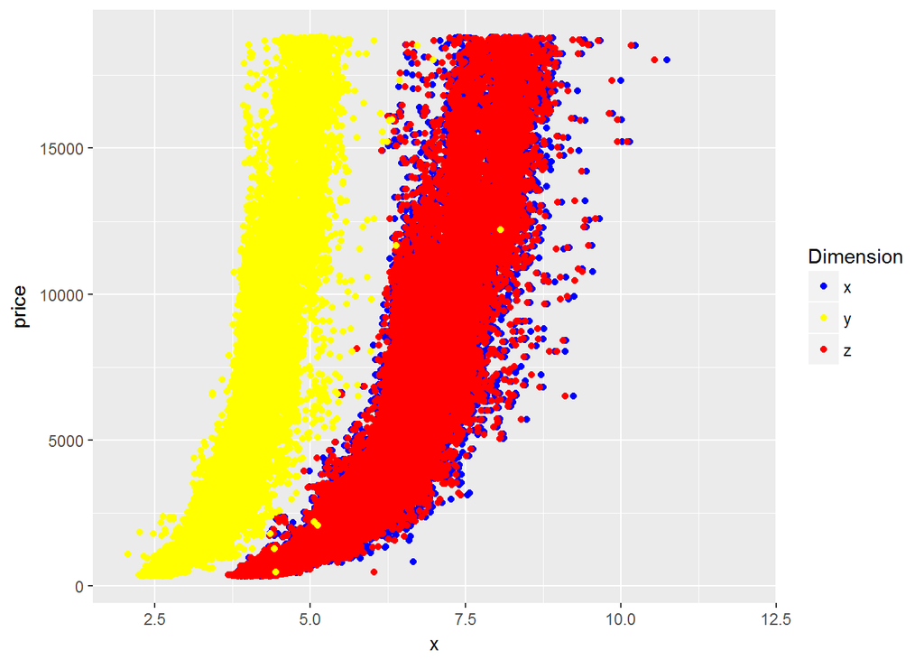

```r
ggplot(diamonds) + geom_point(aes(x = x, y = price , color= "Blue")) +  geom_point(aes(x = y, y = price , color = "Yellow")) +  geom_point(aes(x = z, y = price , color = "Red" )) + xlim(2,12)   + labs (color = "Dimension") + scale_color_manual( values = c("Blue","Yellow","Red"), labels = c("x","y","z"))
```

For predictive model, I splitted data as train and test.

```r
set.seed(503)
library(tidyverse)
diamonds_test <- diamonds %>% mutate(diamond_id = row_number()) %>%
group_by(cut, color, clarity) %>% sample_frac(0.2) %>% ungroup()
diamonds_train <- anti_join(diamonds %>% mutate(diamond_id = row_number()),
diamonds_test, by = "diamond_id")
diamonds_train
```

```
## # A tibble: 43,143 x 11
##    carat cut       color clarity depth table price     x     y     z
##    <dbl> <ord>     <ord> <ord>   <dbl> <dbl> <int> <dbl> <dbl> <dbl>
##  1 0.230 Ideal     E     SI2      61.5  55.0   326  3.95  3.98  2.43
##  2 0.210 Premium   E     SI1      59.8  61.0   326  3.89  3.84  2.31
##  3 0.230 Good      E     VS1      56.9  65.0   327  4.05  4.07  2.31
##  4 0.290 Premium   I     VS2      62.4  58.0   334  4.20  4.23  2.63
##  5 0.240 Very Good J     VVS2     62.8  57.0   336  3.94  3.96  2.48
##  6 0.240 Very Good I     VVS1     62.3  57.0   336  3.95  3.98  2.47
##  7 0.260 Very Good H     SI1      61.9  55.0   337  4.07  4.11  2.53
##  8 0.220 Fair      E     VS2      65.1  61.0   337  3.87  3.78  2.49
##  9 0.230 Very Good H     VS1      59.4  61.0   338  4.00  4.05  2.39
## 10 0.300 Good      J     SI1      64.0  55.0   339  4.25  4.28  2.73
## # ... with 43,133 more rows, and 1 more variable: diamond_id <int>
```

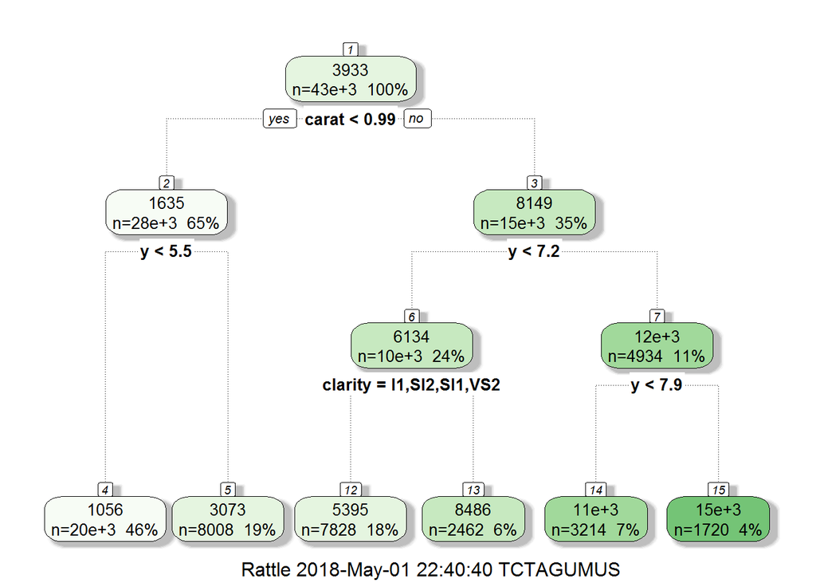

```r
diamonds_model <- rpart(price ~.-diamond_id, data = diamonds_train)
fancyRpartPlot(diamonds_model)
```

```r
diamonds_in_sample <- predict(diamonds_model)
diamonds_comp <- cbind(diamonds_train$price, diamonds_in_sample)
colnames(diamonds_comp) <- c("actual", "predicted")
 diamonds_comp <- data.frame(diamonds_comp)
diamonds_comp$diff <- diamonds_comp$actual -diamonds_comp$predicted
mean(abs(diamonds_comp$diff))
```

```
## [1] 886.1441
```

```r
print(head(diamonds_comp))
```

```
##   actual predicted      diff
## 1    326  1056.168 -730.1677
## 2    326  1056.168 -730.1677
## 3    327  1056.168 -729.1677
## 4    334  1056.168 -722.1677
## 5    336  1056.168 -720.1677
## 6    336  1056.168 -720.1677
```

After train, I added test data to prediction and again calculated error.

```r
diamonds_predict <- predict(diamonds_model, newdata= diamonds_test)
diamonds_comp2 <- cbind(diamonds_test$price, diamonds_predict)
colnames(diamonds_comp2) <- c("actual", "predicted")
diamonds_comp2 <- data.frame(diamonds_comp2)
diamonds_comp2$diff <- diamonds_comp2$actual -diamonds_comp2$predicted
mean(abs(diamonds_comp2$diff))
```

```
## [1] 889.7092
```

```r
print(head(diamonds_comp2))
```

```
##   actual predicted       diff
## 1  15964 14944.339  1019.6610
## 2   3205  3073.487   131.5130
## 3   3384  3073.487   310.5130
## 4   3634  5394.948 -1760.9476
## 5   2358  3073.487  -715.4870
## 6   4398  5394.948  -996.9476
```

# Assignment 3 : Spam Data

This assignment is about analyzing UCT’s Spambase data and building a model on it to detect further possible spam mails according to it’s features.

Firstly, data is loaded and splitted into two parts as given in dataset as test data and train data .

```r
load("/Users/TCTAGUMUS/Documents/R işleri/spam_data.RData")
spam_test <- spam_data %>% filter(train_test == 1 )
spam_train <- spam_data %>% filter(train_test == 0)
```

Then, I built a model with train data using rpart and plotted a decision tree. After, predicted according to our model with train data.

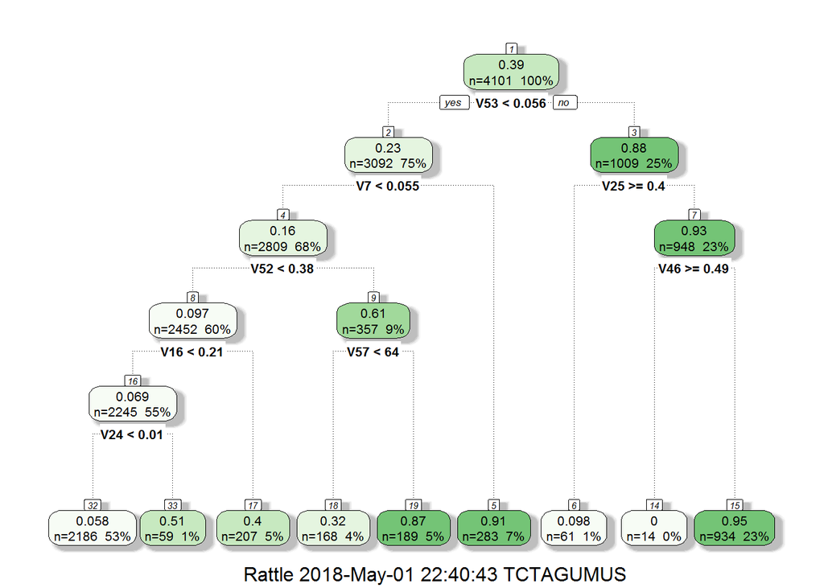

```r
spam_model <- rpart(spam_or_not ~ . -train_test, data = spam_train)
fancyRpartPlot(spam_model)
```

```r
spam_in_sample <- predict(spam_model)
print(head(spam_in_sample))
```

```
##          1          2          3          4          5          6
## 0.86772487 0.94753747 0.94753747 0.90812721 0.90812721 0.05763952
```

To see how good is my model, I compared actual and predicted values of train data. How many correct prediction that my model make divided by total case is a performance indicator for my case.

```r
in_sample_prediction <- cbind(spam_train$spam_or_not , spam_in_sample)
in_sample_prediction = data.frame ( in_sample_prediction)
in_sample_prediction <- in_sample_prediction %>% mutate(V2= ifelse(spam_in_sample>= 0.5 ,1,0)) %>% mutate(is_correct = V1 == V2) %>% group_by(is_correct) %>% summarise(count = n(), percentage = n()/nrow(.))
in_sample_prediction
```

```
## # A tibble: 2 x 3
##   is_correct count percentage
##   <lgl>      <int>      <dbl>
## 1 F            398     0.0970
## 2 T           3703     0.903
```

As we see results above, our model can help to categorize mails into spam or not, with apprx. 9 successfull guess out of 10 tries.

Finally, I repeated steps using test_data.

```r
test_predict <- predict(spam_model, newdata = spam_test)
print(head(test_predict))
```

```
##         1         2         3         4         5         6
## 0.9475375 0.9081272 0.4009662 0.9475375 0.3214286 0.9475375
```

```r
test_prediction <- cbind(spam_test$spam_or_not, test_predict)
test_prediction <- data.frame(test_prediction)
test_prediction <- test_prediction %>% mutate(V2= ifelse(test_predict>= 0.5 ,1,0)) %>% mutate(is_correct = V1 == V2) %>% group_by(is_correct) %>% summarise(count = n(), percentage = n()/nrow(.))
test_prediction
```

```
## # A tibble: 2 x 3
##   is_correct count percentage
##   <lgl>      <int>      <dbl>
## 1 F             50      0.100
## 2 T            450      0.900
```